Elif Cansu Yıldız

← All notebooks

December 8, 2021 9 min read

# Basic Computer Vision Tasks

This notebook consists of calculation of integral image, mean grey value of the image, 2D filtering, generating a noisy image, denoising, separability of filters, Fourier transform on the images, and template matching.

[figure not shown]

# Basic Computer Vision Tasks

```python
import cv2 as cvimport numpy as npimport randomimport osimport sysfrom numpy.random import randintimport matplotlib.pyplot as plt
```

```python
img_path = "data"
```

```python
def show_img(img, title, is_gray=False):    _ = plt.title(title)    if is_gray:        _ = plt.imshow(img, cmap="gray")    else:        _ = plt.imshow(img)
```

## RGB Image

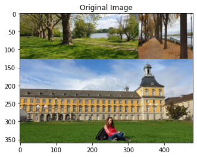

```python
img = cv.imread(os.path.join(img_path, "bonn.png")).astype(np.float32) / 255.0img = cv.cvtColor(img, cv.COLOR_BGR2RGB)if img is None:    print("Could not read the image.")    show_img(img, "Original Image")
```

## Intensity Image

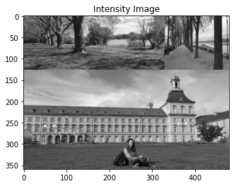

```python
img_gray = cv.cvtColor(img, cv.COLOR_RGB2GRAY)show_img(img_gray, "Intensity Image", is_gray=True)
```

## Small Tasks

**Multiplying the intensity image I by 0.5 and subtracting it from each color channel. Make sure that the values do not become negative, i.e. the new (R, G, B) values are (max(R - 0.5I, 0), max(G - 0.5I, 0), max(B - 0.5I, 0)).**

**Using pixel-wise operations in a nested loop:**

```
3.01 s ± 24 ms per loop (mean ± std. dev. of 7 runs, 1 loop each)
```

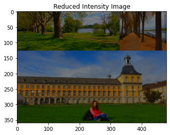

```python
def reduce_intensity_with_loops(img, img_gray):    new_img = img.copy()    for i in range(img.shape[0]):        for j in range(img.shape[1]):            new_img[i,j] = np.clip(img[i,j] - 0.5 * img_gray[i,j], 0, None)    return new_img            %timeit reduce_intensity_with_loops(img, img_gray)new_img = reduce_intensity_with_loops(img, img_gray)show_img(new_img, "Reduced Intensity Image", is_gray=False)
```

**Using one-line python statement:**

```
1.86 ms ± 48.5 µs per loop (mean ± std. dev. of 7 runs, 100 loops each)
```

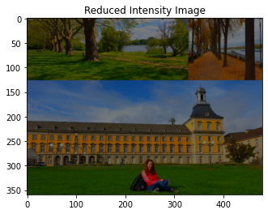

```python
def reduce_intensity_one_line(img, img_gray):    return np.clip(img - 0.5 * np.expand_dims(img_gray, 2), 0, None)%timeit reduce_intensity_one_line(img, img_gray)new_img = reduce_intensity_one_line(img, img_gray)show_img(new_img, "Reduced Intensity Image", is_gray=False)
```

**Extract a 16 × 16 image patch out of the original image centered at the middle of the image, display it, and copy the content to a random location of the image.**

```python
PATCH_SIZE = 16MAX_ELLIPSE_SIZE = 50MIN_ELLIPSE_SIZE = 10MAX_RECT_SIZE = 100MIN_RECT_SIZE = 20
```

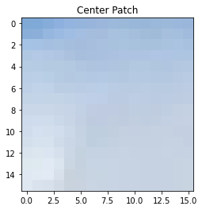

```python
def extract_patch(img):    patch_top, patch_bottom = img.shape[0]//2 - PATCH_SIZE//2 , img.shape[0]//2 + PATCH_SIZE//2    patch_left, patch_right = img.shape[1]//2 - PATCH_SIZE//2 , img.shape[1]//2 + PATCH_SIZE//2    return img[patch_top:patch_bottom, patch_left:patch_right, :]img_patch = extract_patch(img)show_img(img_patch, "Center Patch", is_gray=False)
```

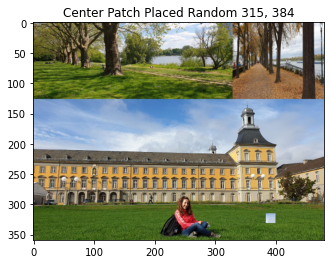

```python
def place_rand_location(img):    rand_coord = randint([img.shape[0]-PATCH_SIZE, img.shape[1]-PATCH_SIZE], size=2)    new_img = img.copy()    new_img[rand_coord[0]:rand_coord[0]+PATCH_SIZE, rand_coord[1]:rand_coord[1]+PATCH_SIZE] = img_patch    return new_img, rand_coordnew_img, rand_coord = place_rand_location(img)show_img(new_img, 'Center Patch Placed Random {}, {}' .format(rand_coord[0], rand_coord[1]), is_gray=False)
```

**Draw 10 random rectangles and 10 random ellipses on the image using rectangle and ellipse and display it. Fill the shapes with colors of your choice.**

```python
def sample_color(saturation=255, value=255):    rand_hue = randint(255,size=1)    rand_color = cv.cvtColor(np.uint8([[[rand_hue, saturation, value]]]), cv.COLOR_HSV2BGR )/255    rand_color = tuple(rand_color[0,0].tolist())    return rand_color
```

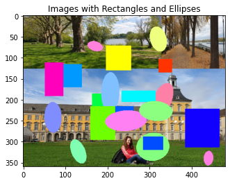

```python
def draw_random_rectangles_ellipses(img):    new_img = img.copy()        for i in range(10):        rand_axes = randint(MIN_ELLIPSE_SIZE, MAX_ELLIPSE_SIZE, size=2)        rand_center = randint((img.shape[1]-rand_axes[0]*2, img.shape[0]-rand_axes[1]*2), size=2) + rand_axes        rand_angle = randint(0,360,size=1)        rand_color = sample_color(saturation=127, value=255)        new_img = cv.ellipse( new_img, rand_center, rand_axes, float(rand_angle), startAngle=0, endAngle=360, color=rand_color, thickness=-1 )         size = randint(MIN_RECT_SIZE, MAX_RECT_SIZE,size=2)        rand_corner1 = randint((img.shape[1]-size[0]*2, img.shape[0]-size[1]*2),size=2) + size        rand_corner2 = (rand_corner1[0] + size[0], rand_corner1[1] + size[1])        rand_hue = randint(255,size=1)        rand_color = sample_color(saturation=255, value=255)        new_img = cv.rectangle(new_img, rand_corner1, rand_corner2, color=rand_color, thickness=-1)            return new_imgnew_img = draw_random_rectangles_ellipses(img)show_img(new_img, "Images with Rectangles and Ellipses", is_gray=False)
```

## Integral Image

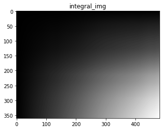

```python
def integral_image(img):    integral_img = np.zeros((img.shape[0]+1, img.shape[1]+1), dtype=np.float32)    for i in range(1, integral_img.shape[0]):        for j in range(1, integral_img.shape[1]):            integral_img[i,j] = integral_img[i,j-1] + integral_img[i-1,j] - integral_img[i-1,j-1]+img[i-1,j-1]    return integral_imgintegral_img = integral_image(img_gray)show_img(integral_img, "integral_img", is_gray=True)
```

**Computing an integral image using the function integral of opencv library**

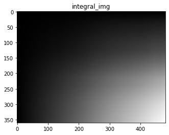

```python
integral_img = cv.integral(img_gray)show_img(integral_img, "integral_img", is_gray=True)
```

## Mean Grey Value of the Image

Average gray value of all pixels in the selection.

In the following task, it can be seen that computing the mean grey value of the image using the integral image is much faster than by summing up each pixel value in the image.

### Summing up each pixel value in the image

```python
def sum_image(img):    return np.sum(img)sum_img = sum_image(img_gray)print(sum_img)
```

```
83389.51
```

### Randomly Cropping an Image

```python
def random_crop(img_shape, crop_size):    i_start = random.randrange( img_shape[0] - crop_size[0] )    j_start = random.randrange( img_shape[1] - crop_size[1] )    i_stop = i_start + crop_size[0]    j_stop = j_start + crop_size[1]    return i_start, i_stop, j_start, j_stop
```

**Select 10 random squares of size 100x100 within the image and compute the mean grey value using the two versions below.**

**1. Using integral image:**

```python
def mean_grey_value_by_integ_img(img, integral_img):    for i in range(10):        i_start, i_stop, j_start, j_stop = random_crop(img.shape, crop_size=(100,100))        pix_sum = integral_img[i_stop, j_stop] - integral_img[i_stop, j_start] - integral_img[i_start, j_stop] + integral_img[i_start, j_start]        pix_mean = pix_sum / (100*100)    return pix_meanintegral_img = integral_image(img_gray)  print("Mean grey value: ", mean_grey_value_by_integ_img(img_gray, integral_img))
```

```
Mean grey value:  0.3255134521484375
```

**2. By summing up each pixel value in the image**

```python
def mean_gray_value_by_summing_pixels(img):    for i in range(10):        i_start, i_stop, j_start, j_stop = random_crop(img.shape, crop_size=(100,100))        img_cropped = img[i_start:i_stop, j_start:j_stop]        pix_mean = np.mean(img_cropped)    return pix_mean%timeit mean_gray_value_by_summing_pixels(img_gray)print("Mean grey value: ", mean_gray_value_by_summing_pixels(img_gray))
```

```
225 µs ± 6.13 µs per loop (mean ± std. dev. of 7 runs, 1000 loops each)
Mean grey value:  0.44674042
```

### Comparing the performance of OpenCV and my implementation

```python
print("Elapsed time of my implementation:")integral_img = integral_image(img_gray)%timeit mean_grey_value_by_integ_img(img_gray, integral_img)print("\nElapsed time of OpenCV function:")integral_img = cv.integral(img_gray)%timeit mean_grey_value_by_integ_img(img_gray, integral_img)
```

```
Elapsed time of my implementation:
47 µs ± 1.09 µs per loop (mean ± std. dev. of 7 runs, 10000 loops each)

Elapsed time of OpenCV function:
25.3 µs ± 701 ns per loop (mean ± std. dev. of 7 runs, 10000 loops each)
```

## 2D Filtering

```python
def gaussian_kernel(sigma, size=(5,5)):    kernel = np.zeros(size)    x = 0 - ((kernel.shape[0])//2)    for i in range(kernel.shape[0]):        y = 0 - ((kernel.shape[1])//2)        for j in range(kernel.shape[1]):            kernel[i,j] = np.exp(-(x**2+y**2)/(2*sigma**2))            y += 1        x += 1    return kernel/np.sum(kernel)
```

[figure not shown]

```python
kernel1 = gaussian_kernel(sigma=2, size=(17,17))kernel2 = gaussian_kernel(sigma=2*np.sqrt(2), size=(17,17))fig, (axs1, axs2) = plt.subplots(1, 2)_ = axs1.imshow(kernel1, cmap="gray")_ = axs1.set_title("kernel with sigma 2")_ = axs2.imshow(kernel1, cmap="gray")_ = axs2.set_title("kernel with sigma 2*sqrt(2)")
```

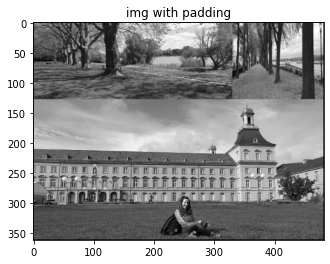

```python
img_padded = np.pad(img_gray, pad_width=(1), mode='constant', constant_values=0)show_img(img_padded, "img with padding", is_gray=True)
```

**Filtering the image twice with a Gaussian kernel with sigma=2**

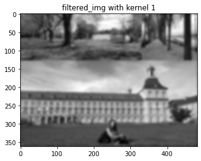

```python
filtered_img = cv.filter2D(img_padded, ddepth=-1, kernel=kernel1)filtered_img = cv.filter2D(filtered_img, ddepth=-1, kernel=kernel1)show_img(filtered_img, "filtered_img with kernel 1", is_gray=True)
```

**Filtering the image once with a Gaussian kernel with sigma=2*sqrt(2)**

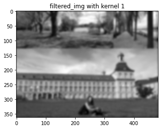

```python
filtered_img2 = cv.filter2D(img_padded, ddepth=-1, kernel=kernel2)show_img(filtered_img2, "filtered_img with kernel 1", is_gray=True)
```

**Absolute pixel-wise difference between the results**

```python
def pixelwise_dif(img1, img2):    #np.max(np.abs(np.subtract(img1,img2)))    return np.max(np.absolute((img1*255).astype(np.int32) - (img2*255).astype(np.int32)))print("maximum pixel error: ", pixelwise_dif(filtered_img, filtered_img2))
```

```
maximum pixel error:  1
```

## Noisy Image

```python
def add_salt_n_pepper_noise(img):    img_flat = img.copy().flatten()    mask = np.random.choice(len(img_flat), int(len(img_flat)*0.3), replace=False)    noise = np.random.choice([0.0,1.0], len(mask))    img_flat[mask] = noise    return img_flat.reshape(img.shape)
```

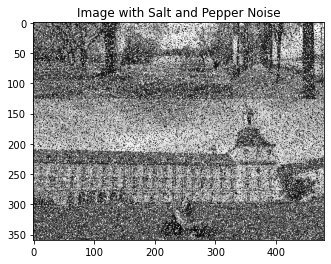

```python
img_noisy = add_salt_n_pepper_noise(img_gray)show_img(img_noisy, 'Image with Salt and Pepper Noise', is_gray=True)
```

## Denoising

```python
kernel_size = 9g_kernel = gaussian_kernel(sigma=2, size=(kernel_size,kernel_size))gaussian_filtered = cv.filter2D(img_noisy, ddepth=-1, kernel=g_kernel)print("maximum pixel error between Gaussian filtered image and original image:\n",                                         pixelwise_dif(gaussian_filtered, img_gray))median_filtered = cv.medianBlur(np.uint8(img_noisy*255), kernel_size) #, cv.BORDER_CONSTANTprint("maximum pixel error between Median filtered image and original image:\n",                                        pixelwise_dif(median_filtered, img_gray))bilateral_filtered = cv.bilateralFilter(img_noisy, kernel_size, kernel_size * 2, kernel_size / 2)print("maximum pixel error between Bilateral filtered image and original image:\n",                                        pixelwise_dif(bilateral_filtered, img_gray))
```

```
maximum pixel error between Gaussian filtered image and original image:
 157
maximum pixel error between Median filtered image and original image:
 249
maximum pixel error between Bilateral filtered image and original image:
 166
```

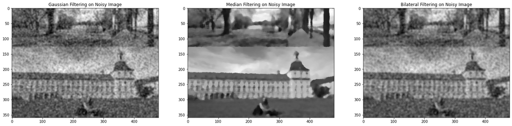

```python
fig, axs = plt.subplots(1, 3, figsize=(25,25))_ = axs[0].imshow(gaussian_filtered, cmap="gray")_ = axs[0].set_title('Gaussian Filtering on Noisy Image')_ = axs[1].imshow(median_filtered, cmap="gray")_ = axs[1].set_title('Median Filtering on Noisy Image')_ = axs[2].imshow(bilateral_filtered, cmap="gray")_ = axs[2].set_title('Bilateral Filtering on Noisy Image')
```

## Separability of Filters

```python
K1 = np.array([[0.0113, 0.0838, 0.0113],               [0.0838, 0.6193, 0.0838],               [0.0113, 0.0838, 0.0113]])K2 = np.array([[-0.8984, 0.1472, 1.1410],               [-1.9075, 0.1566, 2.1359],               [-0.8659, 0.0573, 1.0337]])
```

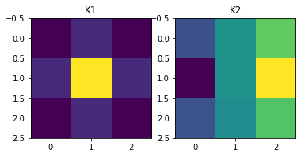

```python
fig, axs = plt.subplots(1, 2)_ = axs[0].imshow(K1);  _ = axs[0].set_title("K1")_ = axs[1].imshow(K2);  _ = axs[1].set_title("K2")
```

**Filtering the image using the two 2D kernels given above**

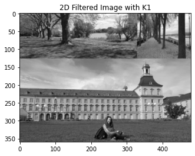

```python
filtered_img1 = cv.filter2D(img_gray, ddepth=-1, kernel=K1)show_img(filtered_img1, 'Filtered Image with K1', is_gray=True)_ = plt.title('2D Filtered Image with K1')_ = plt.imshow(filtered_img1, cmap="gray", vmin=0, vmax=1)
```

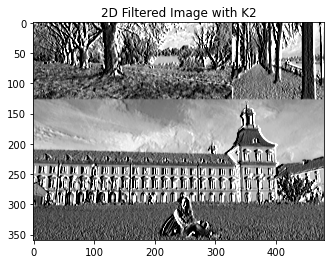

```python
filtered_img2 = cv.filter2D(img_gray, ddepth=-1, kernel=K2)_ = plt.title('2D Filtered Image with K2')_ = plt.imshow(filtered_img2, cmap="gray", vmin=0, vmax=1)
```

**Using the class SVD of OpenCV to seperate each kernel. If a kernel is not separable, used an approximation by taking only the highest singular value. Filtered the images with the obtained 1D kernels.**

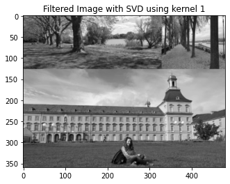

```python
# w: calculated singular values # u: left singular vectors# vt: right singular vectorsw, u, vt = cv.SVDecomp(K1)vertical_kernel = np.sqrt(w[0]) * u[:, 0]horizontal_kernel = np.sqrt(w[0]) * vt[0]filtered_img3 = cv.sepFilter2D(img_gray, ddepth=-1, kernelX=horizontal_kernel, kernelY=vertical_kernel)_ = plt.title('Filtered Image with SVD using kernel 1')_ = plt.imshow(filtered_img3, cmap="gray", vmin=0, vmax=1)
```

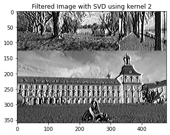

```python
# w: calculated singular values # u: left singular vectors# vt: right singular vectorsw, u, vt = cv.SVDecomp(K2)vertical_kernel = np.sqrt(w[0]) * u[:, 0]horizontal_kernel = np.sqrt(w[0]) * vt[0]filtered_img4 = cv.sepFilter2D(img_gray, ddepth=-1, kernelX=horizontal_kernel, kernelY=vertical_kernel)_ = plt.title('Filtered Image with SVD using kernel 2')_ = plt.imshow(filtered_img4, cmap="gray", vmin=0, vmax=1)
```

```python
print("maximum pixel error between 2D and SVD versions of kernel 1:\n",                                         pixelwise_dif(filtered_img1, filtered_img3))print("maximum pixel error between 2D and SVD versions of kernel 2:\n",                                         pixelwise_dif(filtered_img2, filtered_img4))
```

```
maximum pixel error between 2D and SVD versions of kernel 1:
 1
maximum pixel error between 2D and SVD versions of kernel 2:
 30
```

## Fourier Transform

**The convolution in spatial domain can be computed by multiplication in the frequency domain.**

[figure not shown]

```python
image = cv.imread("data/einstein.jpeg", 0)kernel = cv.getGaussianKernel(ksize=7, sigma=1) kernel = kernel * kernel.Tshow_img(image, "Einstein Image", is_gray=True)
```

[figure not shown]

```python
conv_result = cv.filter2D(image, ddepth=-1, kernel=kernel)show_img(conv_result, "conv_result", is_gray=True)
```

```python
def get_convolution_using_fourier_transform(image, kernel):    img_fft2 = np.fft.fft2(image/255)    kernel_fft2 = np.fft.fft2(kernel, s=img_fft2.shape)     result = np.fft.ifft2(img_fft2 * kernel_fft2)    return np.uint8(result.real * 255)
```

[figure not shown]

```python
fft_result = get_convolution_using_fourier_transform(image, kernel)show_img(fft_result, "fft_result", is_gray=True)
```

```python
def imgs_absolute_mean_error(img1, img2):    return np.mean(np.absolute(np.int32(img1) - np.int32(img2)))
```

```python
print("mean absolute difference of the two blurred images:\n", imgs_absolute_mean_error(conv_result, fft_result))
```

```
mean absolute difference of the two blurred images:
 11.698823529411765
```

## Template Matching

**Template matching using normalized cross-correlation as similarity measures.**

[figure not shown]

```python
image = cv.imread("data/lena.png", 0)template = cv.imread("data/eye.png", 0)fig, axs = plt.subplots(1, 2)_ = axs[0].imshow(image, cmap="gray")_ = axs[1].imshow(template, cmap="gray")
```

[figure not shown]

```python
def normalized_cross_correlation(image, template):    ncc_img = np.zeros(image.shape)    normalized_template = template - np.mean(template)    for i in range(image.shape[0] - template.shape[0]):        for j in range(image.shape[1] - template.shape[1]):            patch = image[i:i+template.shape[0], j:j+template.shape[1]]            normalized_patch = patch - np.mean(patch)            ncc_img[i+template.shape[0]//2 , j+template.shape[1]//2] = np.sum(normalized_template * normalized_patch) / np.sqrt(np.sum(normalized_template**2) * np.sum(normalized_patch**2))    return ncc_imgresult_ncc = normalized_cross_correlation(image, template)_ = plt.imshow(result_ncc, cmap="gray", vmin=0, vmax=1)#show_img(result_ncc, "result_ncc", is_gray=True)
```

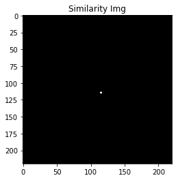

```python
threshold = 0.7similarity_img = np.float32(result_ncc>=threshold)_ = plt.imshow(similarity_img, cmap="gray", vmin=0, vmax=1); _ = plt.title("Similarity Img")
```

[figure not shown]

```python
indexes = np.where(result_ncc>=threshold)img_colored = cv.cvtColor(image, cv.COLOR_GRAY2BGR)for i,j in zip(indexes[0], indexes[1]):    corner1 = (j - template.shape[1]//2, i - template.shape[0]//2)    corner2 = (j + template.shape[1]//2, i + template.shape[0]//2)    img_colored = cv.rectangle(img_colored, corner1, corner2, color=(255,0,0), thickness=1)_ = plt.imshow(img_colored); _ = plt.title("Eye Detection")
```